# A Call Modeling Exploration

Valerie De La Fuente

2025-05-15

## Load Packages and Data

```r
# Load in the libraries
library(tidyverse)
library(sdmTMB)
library(ggplot2)
library(readr)
library(ggcorrplot)
library(Metrics)
library(naniar)
library(tibble)
library(rsample)
library(caret)
library(purrr)
library(tune)
library(patchwork)
library(ggOceanMaps)

# Read in the data
cal_data <- read.csv("../../../data/Merged_CalCOFI/merged_std_data_05_13_25.csv")
```

## Data Cleaning

```r
# Removing the first two columns
cal_data <- cal_data[, -c(1,2)]

# Changing dataset to only have present response data
cal_data <- cal_data %>%
  filter(!is.na(a_scaled))
```

## Exploratory Data Analysis

### Relationship Between Response and Predictors

Ecological data is naturally zero-inflated. Before examining the relationship between A call detection counts and various predictors, it is imperative to remove any values that contain 0 to get a true understanding of the data.

```r
# Duplicate the dataframe
cal_data_cleaned <- cal_data

# Remove A calls with a value of 0
cal_data_cleaned <- cal_data_cleaned %>%
  filter(a_scaled != 0)
```

#### A Calls vs. Longitude

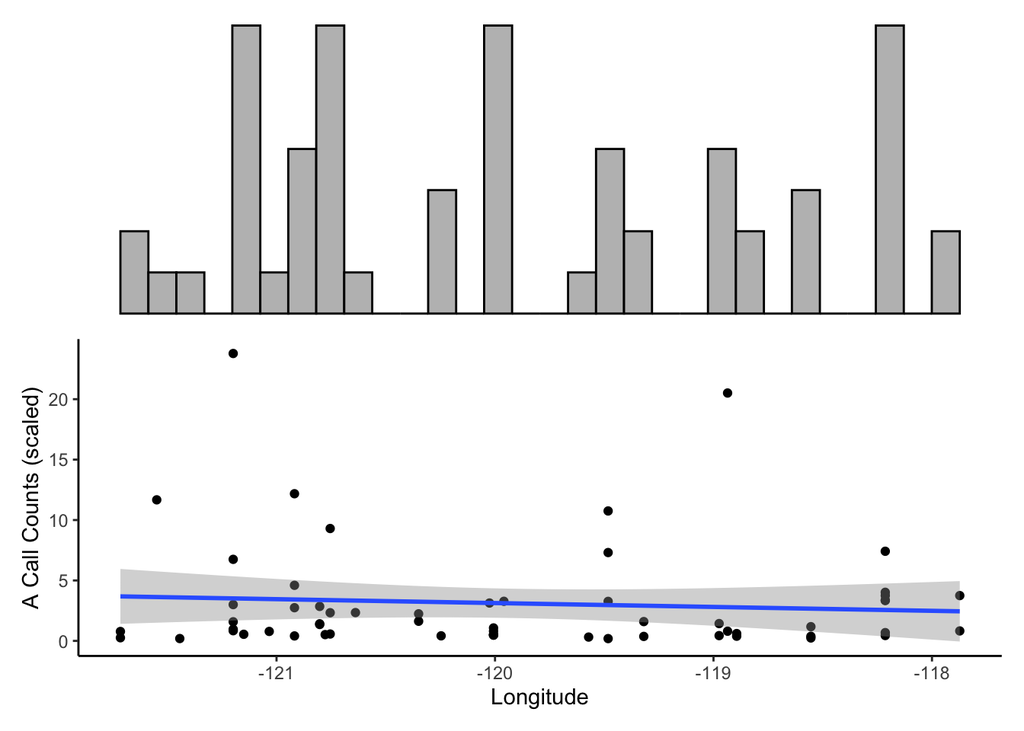

```r
# Create the main scatter plot
p_lon_main <- ggplot(cal_data_cleaned, aes(x = lon, y = a_scaled)) +
  geom_point() +
  geom_smooth(method = "lm") +
  theme_classic() +
  labs(
    x = "Longitude",
    y = "A Call Counts (scaled)"
  )

# Create the histogram for the x-axis
p_lon_hist_x <- ggplot(cal_data_cleaned, aes(x = lon)) +
  geom_histogram(fill = "gray", color = "black") +
  theme_void() +
  theme(axis.text.x = element_blank(),
        axis.ticks.x = element_blank())

# Combine with patchwork
p_lon_hist_x / p_lon_main
```

The histogram shows the frequency of A call detection across different longitude values. There are notable peaks of calls around longitudes -121, -120, and -118.25. This could potentially indicate that these are the areas where blue whales are more active. Additionally, it could indicate migratory paths or feeding grounds along these longitudes.

The scatter plot maps each detection event to a specific longitude. The flat linear regression line suggests that there is no clear linear trend in the number of blue whale calls as longitude changes. However, the spread of data points suggests that while some regions are more densely populated with detections, the relationship is non-linear.

#### A Calls vs. Latitude

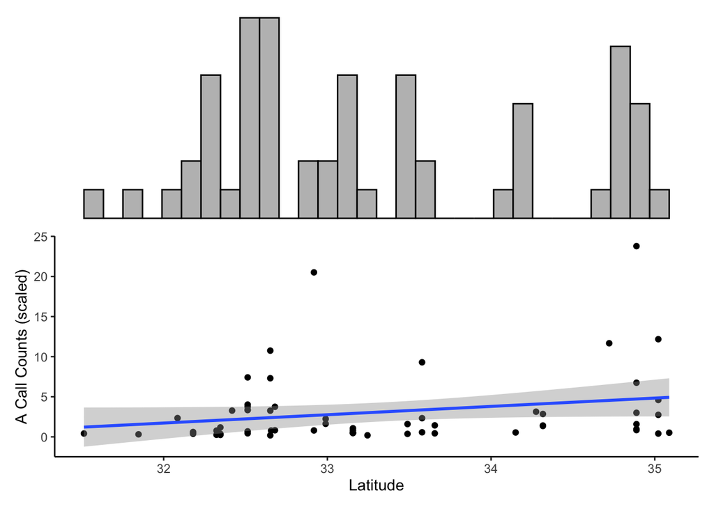

```r
# Create the main scatter plot
p_lat_main <- ggplot(cal_data_cleaned, aes(x = lat, y = a_scaled)) +
  geom_point() +
  geom_smooth(method = "lm") +
  theme_classic() +
  labs(
    x = "Latitude",
    y = "A Call Counts (scaled)"
  )

# Create the histogram for the x-axis
p_lat_hist_x <- ggplot(cal_data_cleaned, aes(x = lat)) +
  geom_histogram(fill = "gray", color = "black") +
  theme_void() +
  theme(axis.text.x = element_blank(),
        axis.ticks.x = element_blank())
# Combine with patchwork
p_lat_hist_x / p_lat_main
```

The histogram represents the frequency of A call detections across different latitudes in the dataset. There are clear peaks around ~32.5. These peaks suggest that A calls are more frequently detected in those specific latitude bands. This could indicate preferred migration paths, feeding grounds, or congregation areas.

The scatter plot maps latitude against the number of A calls detected. There is a slight positive trend, suggesting that as latitude increases, the count of blue whales increase. However, the trend is still weak, as indicated by the broad confidence interval.

#### A Calls vs. Season

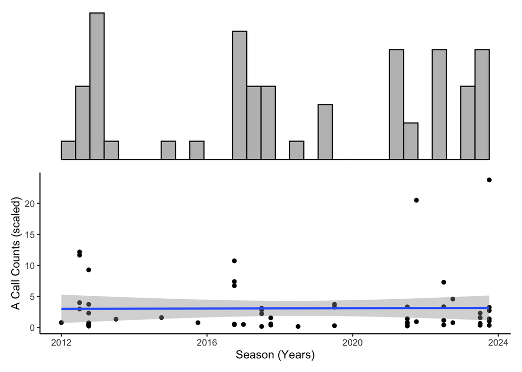

```r
# Create the main scatter plot
p_season_main <- ggplot(cal_data_cleaned, aes(x = season, y = a_scaled)) +
  geom_point() +
  geom_smooth(method = "lm") +
  theme_classic() +
  labs(
    x = "Season (Years)",
    y = "A Call Counts (scaled)"
  )

# Create the histogram for the x-axis
p_season_hist_x <- ggplot(cal_data_cleaned, aes(x = season)) +
  geom_histogram(fill = "gray", color = "black") +
  theme_void() +
  theme(axis.text.x = element_blank(),
        axis.ticks.x = element_blank())

# Combine with patchwork
p_season_hist_x / p_season_main
```

The scatter plot maps season against A call counts. There is a slight positive slope, indicating that detections of A calls have been slightly increasing over time. The confidence interval is quite large, reflecting high variability and less certainty in the trend. Notably, in 2012, 2016, and 2023, there are a few large spikes, which may represent unusually high activity or increased monitoring efforts.

#### A Calls vs. Temperature at Depth 55

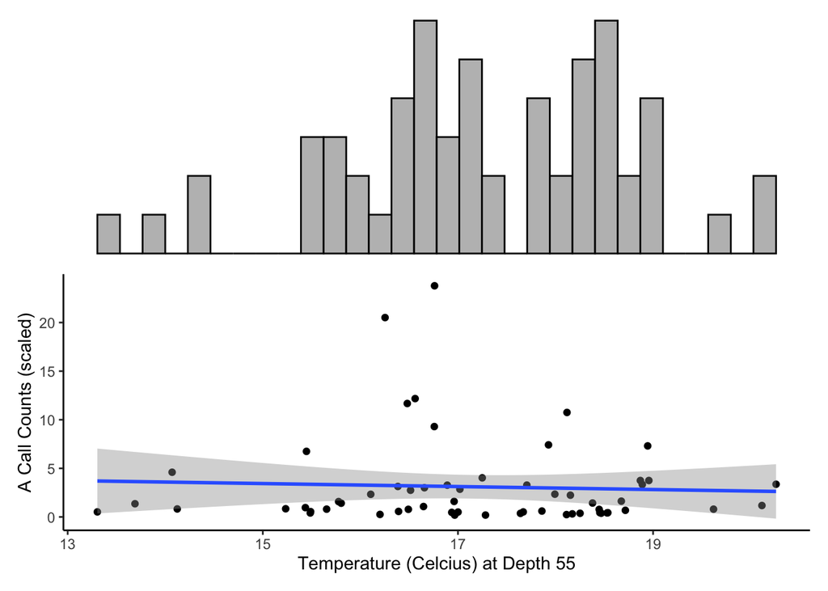

```r
# Create the main scatter plot
p_temp_55_main <- ggplot(cal_data_cleaned, aes(x = temperature_depth_55, y = a_scaled)) +
  geom_point() +
  geom_smooth(method = "lm") +
  theme_classic() +
  labs(
    x = "Temperature (Celcius) at Depth 55",
    y = "A Call Counts (scaled)"
  )

# Create the histogram for the x-axis
p_temp_55_hist_x <- ggplot(cal_data_cleaned, aes(x = temperature_depth_55)) +
  geom_histogram(fill = "gray", color = "black") +
  theme_void() +
  theme(axis.text.x = element_blank(),
        axis.ticks.x = element_blank())

# Combine with patchwork
p_temp_55_hist_x / p_temp_55_main
```

The histogram represents the frequency of A call detections across the distribution of water temperatures at 55m depth. There is a strong concentration between 15.5 and 19 degrees, indicating that most blue whales fall within this range. Sparse readings below 15 degrees and above 19 degrees suggests that those temperatures are less ideal for blue whales.

The scatter plot maps temperature at 55m depth against the number of A calls detected. The slope of the linear regression fit is almost flat, suggesting that the temperature at 55m depth does not have significant linear relationship with the number of A calls. Further, the confidence interval is relatively wide, reflecting high variability in the data.

#### A Calls vs. Temperature at Depth 105

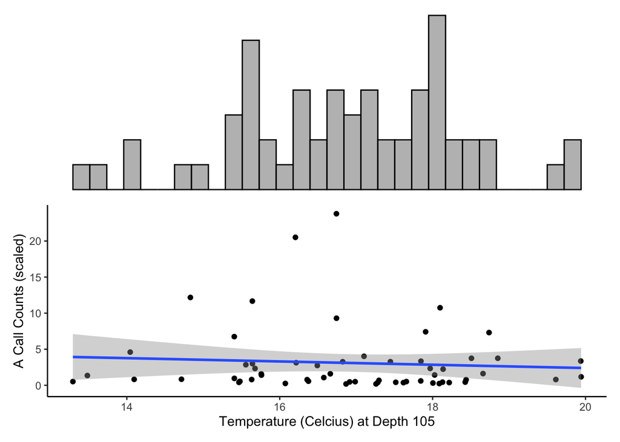

```r
# Create the main scatter plot
p_temp_105_main <- ggplot(cal_data_cleaned, aes(x = temperature_depth_105, y = a_scaled)) +
  geom_point() +
  geom_smooth(method = "lm") +
  theme_classic() +
  labs(
    x = "Temperature (Celcius) at Depth 105",
    y = "A Call Counts (scaled)"
  )

# Create the histogram for the x-axis
p_temp_105_hist_x <- ggplot(cal_data_cleaned, aes(x = temperature_depth_105)) +
  geom_histogram(fill = "gray", color = "black") +
  theme_void() +
  theme(axis.text.x = element_blank(),
        axis.ticks.x = element_blank())

# Combine with patchwork
p_temp_105_hist_x / p_temp_105_main
```

The histogram represents the frequency of A call detections across the distribution of water temperatures at 105m depth. There is a strong concentration between 15 and 19 degrees, indicating that most blue whales fall within this temperature range. Sparse readings below 15 degrees and above 19 degrees suggests that those temperatures are less ideal for blue whales for this depth.

The scatter plot maps temperature at 105m depth against the number of A calls detected. The slope of the linear regression fit is almost flat, suggesting that the temperature at 105m depth does not have significant linear relationship with the number of A calls. Further, the confidence interval is relatively wide, reflecting high variability in the data.

#### A Calls vs. Temperature at Depth 280

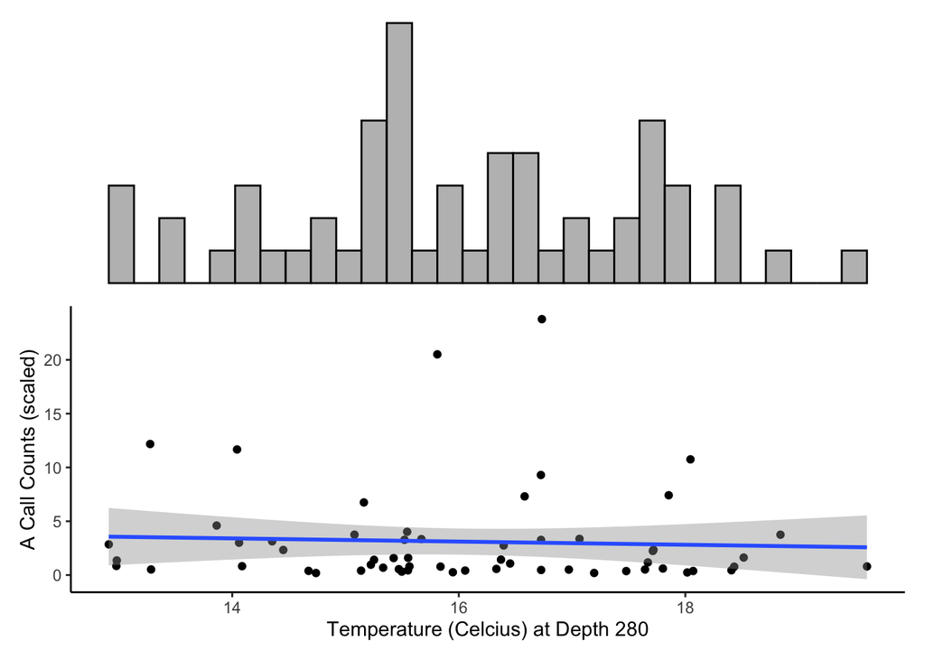

```r
# Create the main scatter plot
p_temp_280_main <- ggplot(cal_data_cleaned, aes(x = temperature_depth_280, y = a_scaled)) +
  geom_point() +
  geom_smooth(method = "lm") +
  theme_classic() +
  labs(
    x = "Temperature (Celcius) at Depth 280",
    y = "A Call Counts (scaled)"
  )

# Create the histogram for the x-axis
p_temp_280_hist_x <- ggplot(cal_data_cleaned, aes(x = temperature_depth_280)) +
  geom_histogram(fill = "gray", color = "black") +
  theme_void() +
  theme(axis.text.x = element_blank(),
        axis.ticks.x = element_blank())

# Combine with patchwork
p_temp_280_hist_x / p_temp_280_main
```

The scatter plot maps temperature at 280m depth against the number of A calls detected. The linear regression fit is almost flat, with a slight negative slope. This suggests that temperature at 280m depth does not significantly correlate with the number of A calls. There is high variability in the scatter, as shown by the wide confidence interval.

#### A Calls vs. Salinity at Depth 55

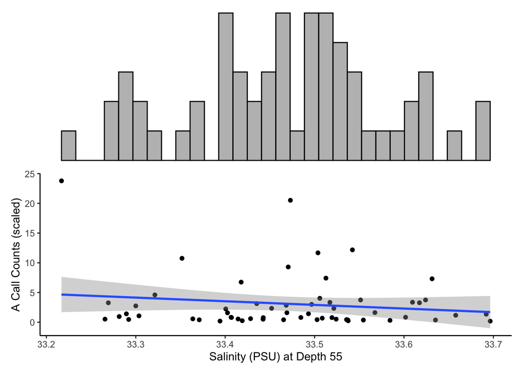

```r
# Create the main scatter plot
p_sal_55_main <- ggplot(cal_data_cleaned, aes(x = salinity_depth_55, y = a_scaled)) +
  geom_point() +
  geom_smooth(method = "lm") +
  theme_classic() +
  labs(
    x = "Salinity (PSU) at Depth 55",
    y = "A Call Counts (scaled)"
  )

# Create the histogram for the x-axis
p_sal_55_hist_x <- ggplot(cal_data_cleaned, aes(x = salinity_depth_55)) +
  geom_histogram(fill = "gray", color = "black") +
  theme_void() +
  theme(axis.text.x = element_blank(),
        axis.ticks.x = element_blank())

# Combine with patchwork
p_sal_55_hist_x / p_sal_55_main
```

The histogram represents the frequency of A calls across the distribution of salinity values at 55m depth. The distribution is bimodal, with peaks at 33.45 and 33.5 PSU. However, the observations are fairly spread with high variability. Very few samples fall between 33.2 to 33.25 and 33.65 to 33.7.

The scatter plot maps salinity at 55m depth against the number of A calls detected. The slope of the linear regression fit is slightly negative, indicating a minor decrease in A calls as salinity increases. The trend is not very strong, but the slope suggests that lower salinity at 55m might be slightly more favorable for A call vocalizations. The confidence interval is wide, implying high variability in the scatter.

#### A Calls vs. Salinity at Depth 105

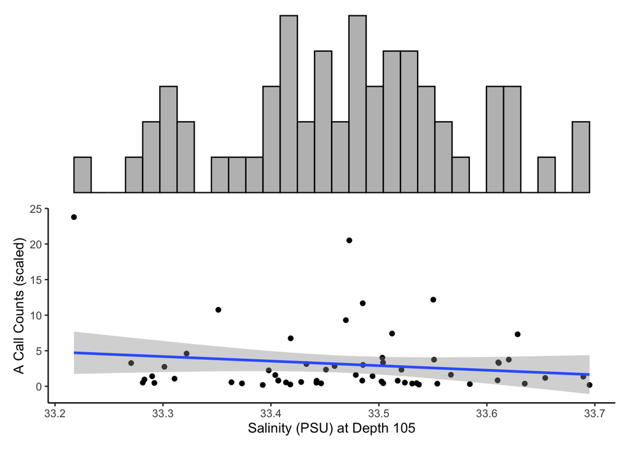

```r
# Create the main scatter plot
p_sal_105_main <- ggplot(cal_data_cleaned, aes(x = salinity_depth_105, y = a_scaled)) +
  geom_point() +
  geom_smooth(method = "lm") +
  theme_classic() +
  labs(
    x = "Salinity (PSU) at Depth 105",
    y = "A Call Counts (scaled)"
  )

# Create the histogram for the x-axis
p_sal_105_hist_x <- ggplot(cal_data_cleaned, aes(x = salinity_depth_105)) +
  geom_histogram(fill = "gray", color = "black") +
  theme_void() +
  theme(axis.text.x = element_blank(),
        axis.ticks.x = element_blank())

# Combine with patchwork
p_sal_105_hist_x / p_sal_105_main
```

The histogram represents the frequency of A calls across the distribution of salinity values at 105m depth. The distribution is fairly normal and clustered around 33.35 to 33.6 PSU with most A calls occurring within that range. There is a noticeable peak at 33.41 and 33.48 PSU.

The scatter plot maps salinity at 105m depth against the number of A calls detected. The slope of the linear regression fit is slightly negative, indicating a minor decrease in A calls as salinity increases at depth 105m. The trend is not very strong, but the slope suggests that lower salinity at 105m might be slightly more favorable for A call vocalizations. The confidence interval is wide, implying high variability in the scatter.

#### A Calls vs. Salinity at Depth 280

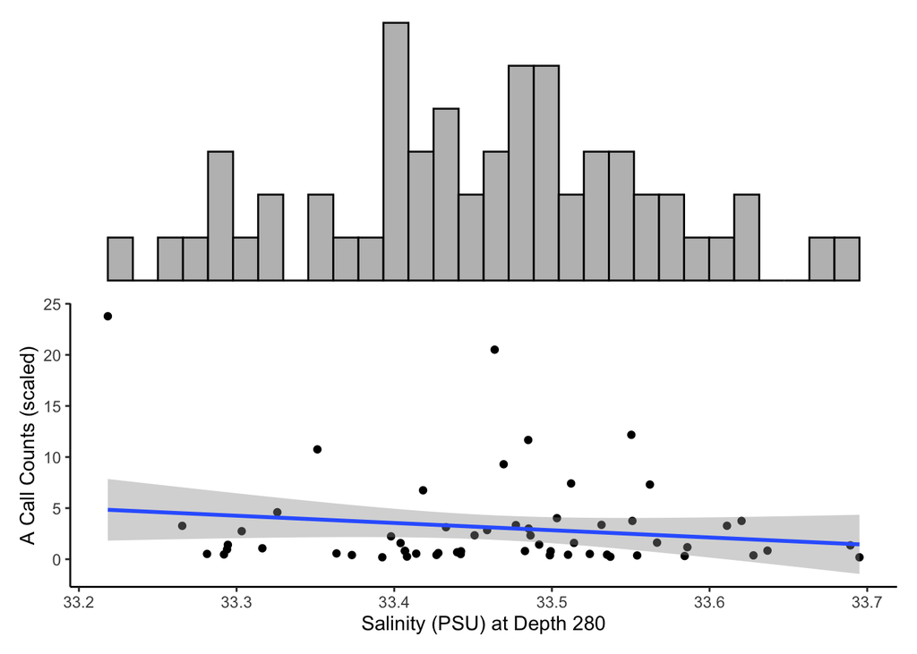

```r
# Create the main scatter plot
p_sal_280_main <- ggplot(cal_data_cleaned, aes(x = salinity_depth_280, y = a_scaled)) +
  geom_point() +
  geom_smooth(method = "lm") +
  theme_classic() +
  labs(
    x = "Salinity (PSU) at Depth 280",
    y = "A Call Counts (scaled)"
  )

# Create the histogram for the x-axis
p_sal_280_hist_x <- ggplot(cal_data_cleaned, aes(x = salinity_depth_280)) +
  geom_histogram(fill = "gray", color = "black") +
  theme_void() +
  theme(axis.text.x = element_blank(),
        axis.ticks.x = element_blank())

# Combine with patchwork
p_sal_280_hist_x / p_sal_280_main
```

The histogram represents the frequency of A calls across the distribution of salinity values at 280m depth. The salinity is tightly clustered between 33.35 to 33.65 PSU. There is a strong peak around 33.4 PSU, suggesting this is the most frequently observed salinity range at this depth in the dataset. A few samples appear on the edges near 33.2 and 33.7, but they are rare.

The scatter plot maps salinity at 280m depth against the number of A calls detected. The slope of the linear regression fit indicates that as salinity increases, the number of A calls slightly decrease. The trend is more apparent here compared to the 55m salinity plot.

#### A Calls vs. Magnitude at Depth 55

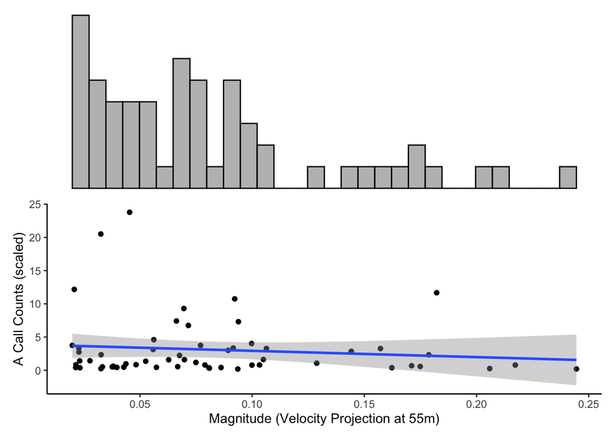

```r
# Create the main scatter plot
p_mag_55_main <- ggplot(cal_data_cleaned, aes(x = magnitude_depth_55, y = a_scaled)) +
  geom_point() +
  geom_smooth(method = "lm") +
  theme_classic() +
  labs(
    x = "Magnitude (Velocity Projection at 55m)",
    y = "A Call Counts (scaled)"
  )

# Create the histogram for the x-axis
p_mag_55_hist_x <- ggplot(cal_data_cleaned, aes(x = magnitude_depth_55)) +
  geom_histogram(fill = "gray", color = "black") +
  theme_void() +
  theme(axis.text.x = element_blank(),
        axis.ticks.x = element_blank())

# Combine with patchwork
p_mag_55_hist_x / p_mag_55_main
```

The histogram represents the frequency of A calls across the distribution of magnitude projections at 55m depth. There is a clear clustering towards the left (0.00 to ~0.11), indicating that most of the velocity projections at this depth are relatively small. There is a sparse distribution beyond 0.125. This distribution is right-skewed, suggesting that higher magnitudes are rare in this dataset.

The scatter plot maps the relationship between magnitude projections at 55m depth and the frequency of A calls. The slope of the linear regression line is nearly flat with a slight negative slope, indicating that:

- As the magnitude of velocity increases, there is a very slight decrease in A calls detected.
- The slope is small, so the effect is minimal.

The confidence interval is relatively wide, suggesting that there is high variability in the relationship.

#### A Calls vs. Magnitude at Depth 105

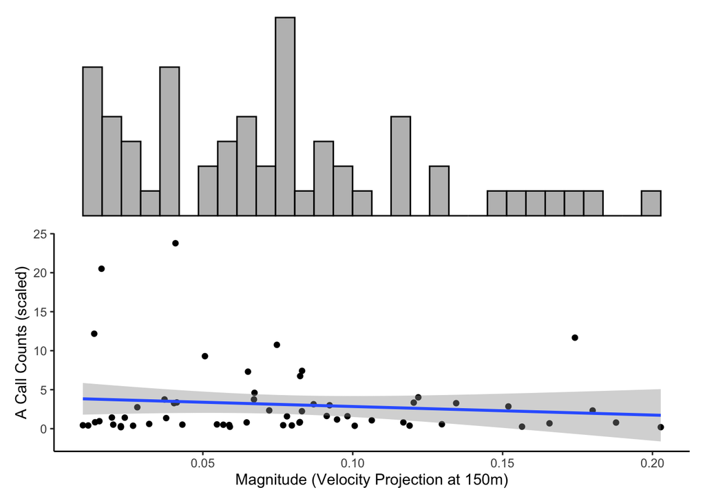

```r
# Create the main scatter plot
p_mag_105_main <- ggplot(cal_data_cleaned, aes(x = magnitude_depth_105, y = a_scaled)) +
  geom_point() +
  geom_smooth(method = "lm") +
  theme_classic() +
  labs(
    x = "Magnitude (Velocity Projection at 150m)",
    y = "A Call Counts (scaled)"
  )

# Create the histogram for the x-axis
p_mag_105_hist_x <- ggplot(cal_data_cleaned, aes(x = magnitude_depth_105)) +
  geom_histogram(fill = "gray", color = "black") +
  theme_void() +
  theme(axis.text.x = element_blank(),
        axis.ticks.x = element_blank())

# Combine with patchwork
p_mag_105_hist_x / p_mag_105_main
```

The histogram represents the frequency of A calls across the distribution of magnitude projections at 105m depth. There is a clear clustering towards the left (0.00 to ~0.13), indicating that most of the velocity projections at this depth are relatively small. There is a sparse distribution beyond 0.15. While this dataset is still right-skewed, the data is more widely spread than magnitude projections at 55m depth. This might suggest that as ocean depth increases, blue whales are more inclined to make A calls at increased magnitude projections.

The scatter plot maps the relationship between magnitude projections at 105m depth and the frequency of A calls. The slope of the linear regression line is nearly flat with a slight negative slope, indicating that:

- As the magnitude of velocity increases, there is a very slight decrease in A calls detected.
- The slope is small, so the effect is minimal.

The confidence interval is relatively wide, suggesting that there is high variability in the relationship.

#### A Calls vs. Magnitude at Depth 280

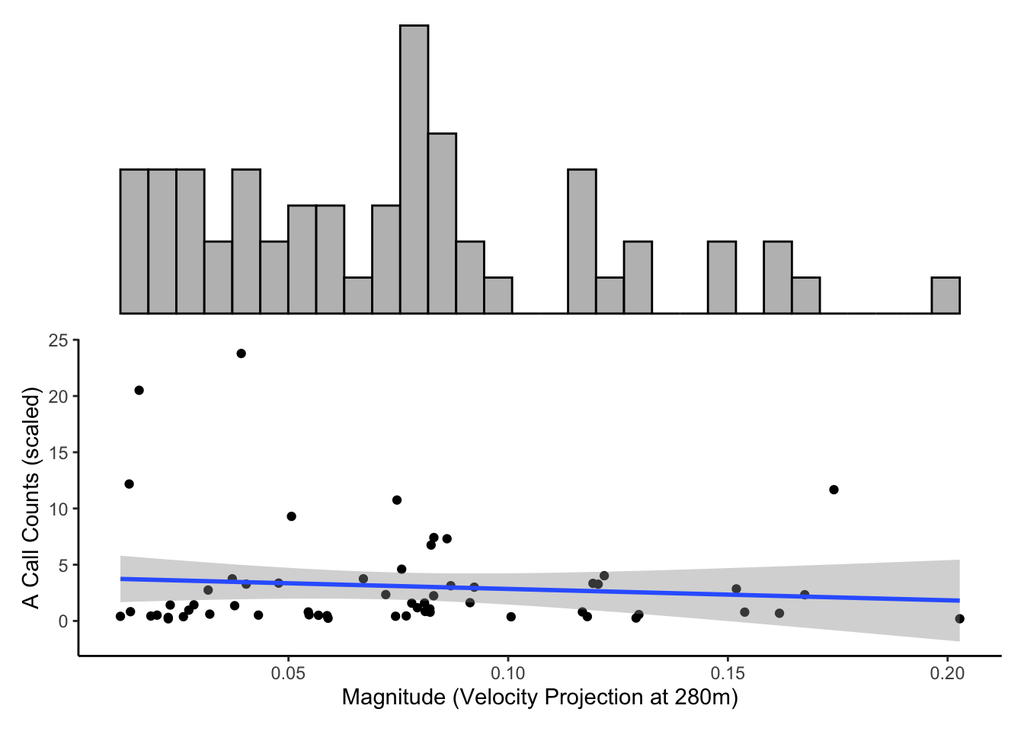

```r
# Create the main scatter plot
p_mag_280_main <- ggplot(cal_data_cleaned, aes(x = magnitude_depth_280, y = a_scaled)) +
  geom_point() +
  geom_smooth(method = "lm") +
  theme_classic() +
  labs(
    x = "Magnitude (Velocity Projection at 280m)",
    y = "A Call Counts (scaled)"
  )

# Create the histogram for the x-axis
p_mag_280_hist_x <- ggplot(cal_data_cleaned, aes(x = magnitude_depth_280)) +
  geom_histogram(fill = "gray", color = "black") +
  theme_void() +
  theme(axis.text.x = element_blank(),
        axis.ticks.x = element_blank())

# Combine with patchwork
p_mag_280_hist_x / p_mag_280_main
```

The histogram represents the frequency of A calls across the distribution of magnitude projections at 280m depth. There is clear clustering toward the left (0.00 to ~0.10), indicating that low magnitude projections are the most common at this depth. A few outliers exist beyond 0.15, suggesting rare instances of stronger projected velocities. The distribution is right-skewed, with most observations concentrated around smaller magnitudes, similar to what was seen at 55m at 105m.

The scatter plot maps the relationship between the magnitude of velocity at 280m and the count of A calls. The slope of the linear regression line is nearly flat with a very slight negative slope, suggesting that there is no strong linear relationship present. A minor decrease in call counts as magnitude increases is observed, but it is not substantial. The wide confidence interval indicates high variability and low confidence in the estimated relationship.

#### A Calls vs. Theta at Depth 55

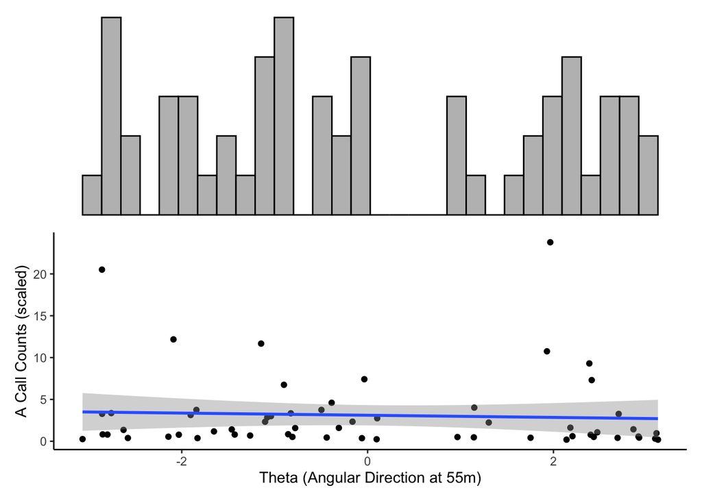

```r
# Create the main scatter plot
p_theta_55_main <- ggplot(cal_data_cleaned, aes(x = theta_depth_55, y = a_scaled)) +
  geom_point() +
  geom_smooth(method = "lm") +
  theme_classic() +
  labs(
    x = "Theta (Angular Direction at 55m)",
    y = "A Call Counts (scaled)"
  )

# Create the histogram for the x-axis
p_theta_55_hist_x <- ggplot(cal_data_cleaned, aes(x = theta_depth_55)) +
  geom_histogram(fill = "gray", color = "black") +
  theme_void() +
  theme(axis.text.x = element_blank(),
        axis.ticks.x = element_blank())

# Combine with patchwork
p_theta_55_hist_x / p_theta_55_main
```

The histogram represents the frequency of A calls across the distribution of theta projections at 55m depth. The distribution is split, with clusters from -3 to -0 and 1 to 3. This indicates that water flow tends to follow those specific directional patterns more frequently. The gaps in the histogram suggest less frequent flow in certain angular directions, possibly representing less common ocean currents or directional shifts at a depth of 55m. There is a noticeable peak around -3 and -1, indicating that this is the most common angular direction for an A call to be detected.

The scatter plot displays the relationship between the angular direction of flow at 55m depth and the number of A calls detected. The slope of the linear regression line is mostly flat with a slight negative slope, implying that:

- There is no strong linear correlation between the direction of ocean current flow and the number of blue whale calls.
- The distribution of points does not favor any specific angular direction with increased vocalizations.

The wide confidence interval highlights the high variability in A call counts across different flow directions. There is no clear preference or avoidance of whales in terms of the water current’s angular direction at a depth of 55m.

#### A Calls vs. Theta at Depth 105

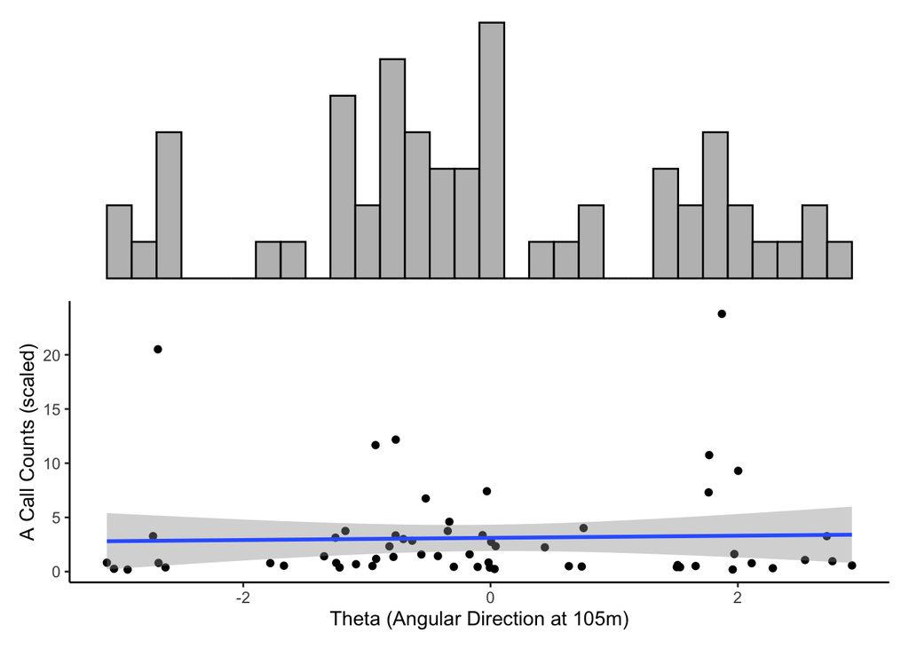

```r
# Create the main scatter plot
p_theta_105_main <- ggplot(cal_data_cleaned, aes(x = theta_depth_105, y = a_scaled)) +
  geom_point() +
  geom_smooth(method = "lm") +
  theme_classic() +
  labs(
    x = "Theta (Angular Direction at 105m)",
    y = "A Call Counts (scaled)"
  )

# Create the histogram for the x-axis
p_theta_105_hist_x <- ggplot(cal_data_cleaned, aes(x = theta_depth_105)) +
  geom_histogram(fill = "gray", color = "black") +
  theme_void() +
  theme(axis.text.x = element_blank(),
        axis.ticks.x = element_blank())

# Combine with patchwork
p_theta_105_hist_x / p_theta_105_main
```

The histogram represents the frequency of A calls across the distribution of theta projections at 105m depth. There are data is clustered throughout, with the most notable cluster being between -1 and 0. There is a noticeable peak around 0, suggesting a strong current direction that is repeated often in that angular region. There are several gaps where flow is less common, indicating directional biases in current flow.

The scatter plot displays the relationship between the angular direction of flow (theta) at 105m depth and the number of A calls detected. The slop of the linear regression line is nearly flat with a slight positive slope. This suggests that there is no strong linear relationship between the direction of water flow at 105m and the number of blue whale vocalizations. The slight upward trend is not significantly significant as indicated by the wide confidence interval. There are outliers around -3 and +2 in the angular direction with some higher call rates, but they are sparse and isolated. The scatter distribution is wide and not concentrated around any specific direction.

#### A Calls vs. Theta at Depth 280

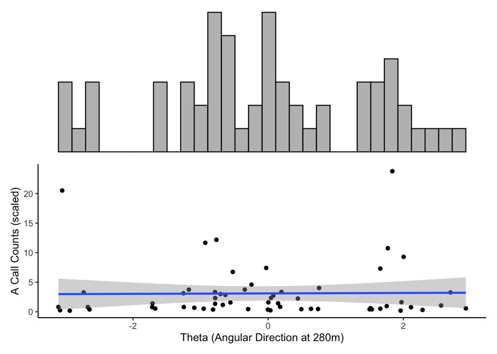

```r
# Create the main scatter plot
p_theta_280_main <- ggplot(cal_data_cleaned, aes(x = theta_depth_280, y = a_scaled)) +
  geom_point() +
  geom_smooth(method = "lm") +
  theme_classic() +
  labs(
    x = "Theta (Angular Direction at 280m)",
    y = "A Call Counts (scaled)"
  )

# Create the histogram for the x-axis
p_theta_280_hist_x <- ggplot(cal_data_cleaned, aes(x = theta_depth_280)) +
  geom_histogram(fill = "gray", color = "black") +
  theme_void() +
  theme(axis.text.x = element_blank(),
        axis.ticks.x = element_blank())

# Combine with patchwork
p_theta_280_hist_x / p_theta_280_main
```

The histogram represents the frequency of A calls across the distribution of theta projections at 280m depth. There are clear peaks around -1 and 0. These peaks suggest preferred flow directions at 280m depth, potentially driven by ocean currents. However, the data is clustered and the gaps in certain regions suggest less frequent flow in those angular directions.

The scatter plot displays the relationship between the angular direction of flow (theta) at 280m depth and the number of A calls detected. The slope of the linear regression line is mostly flat, with a very slight positive slope. This indicates that there is no strong linear correlation between the direction of water flow and the number of whale vocalizations at this depth. The slight upward slope is not statistically significant given the wide confidence interval. There are outliers with higher call counts at around -3 and +2. However, these outliers are sparse and do not seem to follow a clear directional preference.

### Spatiotemporal Visualization of A Call Detections

The following visualization shows the count of observed A calls from the years 2012 - 2023 across the Southern California Bight. It is represented across binned seasons and years with specified spatial coordinates.

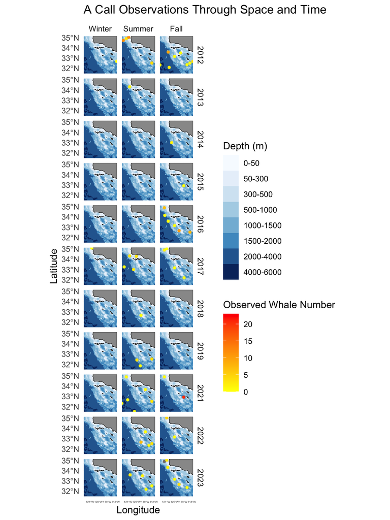

```r
# Define season labels for facet
season_labels <- c(
  "0" = "Winter",
  "0.25" = "Spring",
  "0.5" = "Summer",
  "0.75" = "Fall"
)

basemap(data = cal_data_cleaned, bathymetry = TRUE) +
  geom_point(data = cal_data_cleaned, aes(x = lon, y = lat, color = a_scaled), size = 1) +
  scale_color_gradient(low = "yellow", high = "red", limits = c(0, 23)) +
  labs(
    title = "A Call Observations Through Space and Time",
    x = "Longitude", y = "Latitude",
    color = "Observed Whale Number"
  ) +
  theme_minimal() +
  theme(axis.text.x = element_text(size = 3)) +
  facet_grid(
    rows = vars(year),
    cols = vars(season_decimal),
    labeller = labeller(season_decimal = season_labels)
  )
```

### Correlation Plot

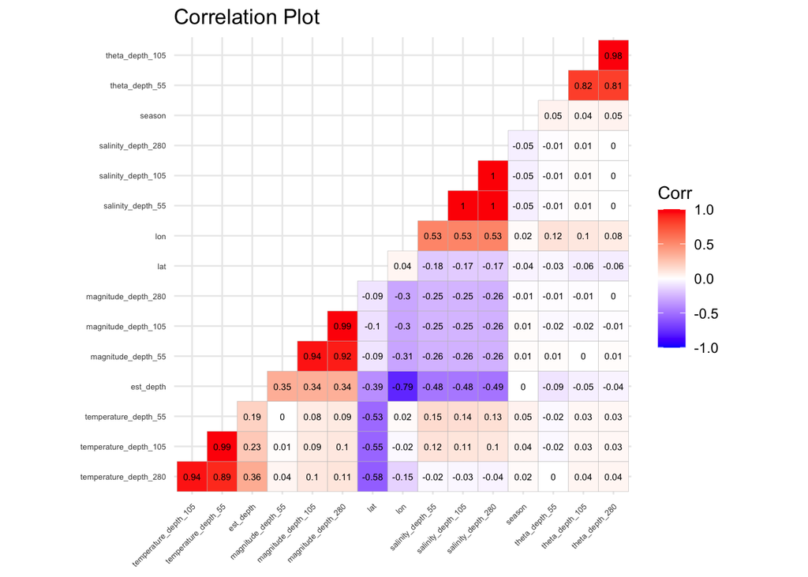

```r
# Plotting Correlation
# Define expected columns
cols_to_use <- c("est_depth", "temperature_depth_105", "temperature_depth_280", "temperature_depth_55",
                 "salinity_depth_105", "salinity_depth_280", "salinity_depth_55",
                 "magnitude_depth_105", "magnitude_depth_280", "magnitude_depth_55",
                 "theta_depth_105", "theta_depth_280", "theta_depth_55",
                 "lon", "lat", "season")

# Keep only existing columns
existing_cols <- intersect(cols_to_use, colnames(cal_data))
cor_data <- cal_data[, existing_cols, drop = FALSE]

# Compute correlation matrix (use complete.obs to skip missing data)
cor_matrix <- cor(cor_data, use = "complete.obs")

# Correlation plot
ggcorrplot(cor_matrix,
           lab = TRUE,
           hc.order = TRUE,
           lab_size =2,
           tl.cex = 5,
           type = "lower",
           title = "Correlation Plot")
```

There are several key relationships to observe in the graph. The environmental predictors demonstrate a near-perfect positive correlation within their respective categories (e.g., `temperature_depth_55`, `temperature_depth_105`, and `temperature_depth_280`), highlighting consistent changes across different depths. Additionally, `est_depth` appears to have a negative correlation with most predictors, particularly with `lon,` suggesting that as the estimated depth increases, longitudinal positioning tends to shift in the opposite direction. Another notable relationship is between `lon` and `salinity_depth_55`, `salinity_depth_105`, and `salinity_depth_280`. This relationship exhibits a moderately strong positive correlation, potentially indicating that increases in salinity at various depths are systematically linked to changes in longitudinal position. This pattern could reflect underlying oceanographic processes, such as saline water masses being distributed along specific longitudinal gradients. Understanding these spatial relationships can provide insight into regional salinity dynamics and their interaction with environmental factors.

### Missing Data

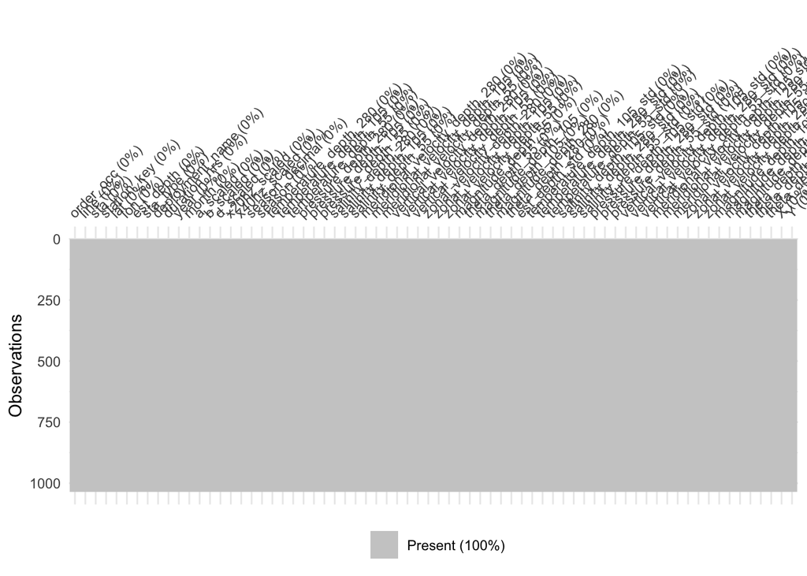

```r
# Visualize missing data
missing_data_plot <- naniar::vis_miss(cal_data)
print(missing_data_plot)
```

There is no missing data present in this dataset. All observations with missing A call counts have been removed.

## Splitting the Data

```r
# Split data into training and testing sets with most recent year as our testing set
set.seed(123)
last_year <- max(cal_data$year)
train_data <- cal_data %>% filter(year != last_year)
test_data <- cal_data %>% filter(year == last_year)
```

## Modeling

### Intercept Modeling

##### Intercept with `spatialtemporal = "rw"`

```r
# Create mesh using training data
mesh_train <- make_mesh(train_data,
                        xy_cols = c("X", "Y"),
                        cutoff = 5)

# Fit spatiotemporal model
fit_1 <- sdmTMB(
  a_scaled ~ 1,
  data = train_data,
  mesh = mesh_train,
  time = "season",
  family = delta_gamma(link1 = "logit", link2 = "log"),
  spatial = "on",
  spatiotemporal = "rw",
  extra_time = unique(test_data$season)
)

# Predictions on training and test data
training_pred <- predict(fit_1, newdata = train_data, type = "response")
training_pred$observed <- train_data$a_scaled

test_pred <- predict(fit_1, newdata = test_data, type = "response")
test_pred$observed <- test_data$a_scaled

# Compute RMSE
rmse_train <- rmse(training_pred$observed, training_pred$est)
rmse_test <- rmse(test_pred$observed, test_pred$est)

# Compute Range
range_train <- range(train_data$a_scaled)
range_test <- range(test_data$a_scaled)

# Compute Standard Deviation
sd_train <- sd(train_data$a_scaled, na.rm = TRUE)
sd_test <- sd(test_data$a_scaled, na.rm = TRUE)

# Assemble the table
summary_table_1 <- data.frame(
  Dataset = c("Training", "Test"),
  RMSE = c(rmse_train, rmse_test),
  Range_Min = c(range_train[1], range_test[1]),
  Range_Max = c(range_train[2], range_test[2]),
  Std_Dev = c(sd_train, sd_test)
)

# Save summary table
saveRDS(summary_table_1, file = "a_call_models/summary_table_1.rds")
```

```r
# Load the summary table back in
summary_table_1 <- readRDS("a_call_models/summary_table_1.rds")

# Print the summary table
print(summary_table_1)
```

```
##    Dataset     RMSE Range_Min Range_Max  Std_Dev
## 1 Training 1.041377         0  20.51083 1.147824
## 2     Test 2.101623         0  23.78094 2.137205
```

### Modeling with Environmental Predictors at Different Depths

Now we are introducing environmental predictors to the model. We will be looking into environmental predictors at each depth.

#### Depth 55

Four models were run using environmental predictors at a depth of 55, differing in the inclusion of splines and spatial coordinates as predictors. Test RMSEs were compared to identify the most suitable parameters for future models.

##### Generalized Additive Model (GAM) with Spline-Adjusted Environmental Predictors

```r
# Create mesh using training data
mesh_train <- make_mesh(train_data,
                        xy_cols = c("X", "Y"),
                        cutoff = 5)

# Fit spatiotemporal model
fit_3 <- sdmTMB(
  a_scaled ~ s(temperature_depth_55) + s(salinity_depth_55) + s(magnitude_depth_55) + s(theta_depth_55),
  data = train_data,
  mesh = mesh_train,
  time = "season",
  family = delta_gamma(link1 = "logit", link2 = "log"),
  spatial = "on",
  spatiotemporal = "rw",
  extra_time = unique(test_data$season)
)

# Predictions on training and test data
training_pred <- predict(fit_3, newdata = train_data, type = "response")
training_pred$observed <- train_data$a_scaled

test_pred <- predict(fit_3, newdata = test_data, type = "response")
test_pred$observed <- test_data$a_scaled

# Compute RMSE
rmse_train <- rmse(training_pred$observed, training_pred$est)
rmse_test <- rmse(test_pred$observed, test_pred$est)

# Compute Range
range_train <- range(train_data$a_scaled)
range_test <- range(test_data$a_scaled)

# Compute Standard Deviation
sd_train <- sd(train_data$a_scaled, na.rm = TRUE)
sd_test <- sd(test_data$a_scaled, na.rm = TRUE)

# Assemble the table
summary_table_3 <- data.frame(
  Dataset = c("Training", "Test"),
  RMSE = c(rmse_train, rmse_test),
  Range_Min = c(range_train[1], range_test[1]),
  Range_Max = c(range_train[2], range_test[2]),
  Std_Dev = c(sd_train, sd_test)
)

# Save summary table
saveRDS(summary_table_3, file = "a_call_models/summary_table_3.rds")
```

```r
# Load the summary table back in
summary_table_3 <- readRDS("a_call_models/summary_table_3.rds")

# Print the summary table
print(summary_table_3)
```

```
##    Dataset     RMSE Range_Min Range_Max  Std_Dev
## 1 Training 1.075918         0  20.51083 1.147824
## 2     Test 1.999732         0  23.78094 2.137205
```

##### Generalized Linear Mixture Model (GLMM) with Linearly Treated Environmental Predictors

```r
# Create mesh using training data
mesh_train <- make_mesh(train_data,
                        xy_cols = c("X", "Y"),
                        cutoff = 5)

# Fit spatiotemporal model
fit_11 <- sdmTMB(
  a_scaled ~ temperature_depth_55 + salinity_depth_55 + magnitude_depth_55 + theta_depth_55,
  data = train_data,
  mesh = mesh_train,
  time = "season",
  family = delta_gamma(link1 = "logit", link2 = "log"),
  spatial = "on",
  spatiotemporal = "rw",
  extra_time = unique(test_data$season)
)

# Predictions on training and test data
training_pred <- predict(fit_11, newdata = train_data, type = "response")
training_pred$observed <- train_data$a_scaled

test_pred <- predict(fit_11, newdata = test_data, type = "response")
test_pred$observed <- test_data$a_scaled

# Compute RMSE
rmse_train <- rmse(training_pred$observed, training_pred$est)
rmse_test <- rmse(test_pred$observed, test_pred$est)

# Compute Range
range_train <- range(train_data$a_scaled)
range_test <- range(test_data$a_scaled)

# Compute Standard Deviation
sd_train <- sd(train_data$a_scaled, na.rm = TRUE)
sd_test <- sd(test_data$a_scaled, na.rm = TRUE)

# Assemble the table
summary_table_11 <- data.frame(
  Dataset = c("Training", "Test"),
  RMSE = c(rmse_train, rmse_test),
  Range_Min = c(range_train[1], range_test[1]),
  Range_Max = c(range_train[2], range_test[2]),
  Std_Dev = c(sd_train, sd_test)
)

# Save summary table
saveRDS(summary_table_11, file = "a_call_models/summary_table_11.rds")
```

```r
# Load the summary table back in
summary_table_11 <- readRDS("a_call_models/summary_table_11.rds")

# Print the summary table
print(summary_table_11)
```

```
##    Dataset     RMSE Range_Min Range_Max  Std_Dev
## 1 Training 1.080455         0  20.51083 1.147824
## 2     Test 2.027464         0  23.78094 2.137205
```

##### Generalized Linear Mixture Model (GLMM) with Linearly Treated Environmental Predictors and Spatial Predictors

```r
# Create mesh using training data
mesh_train <- make_mesh(train_data,
                        xy_cols = c("X", "Y"),
                        cutoff = 5)

# Fit spatiotemporal model
fit_8 <- sdmTMB(
  a_scaled ~ temperature_depth_55 + salinity_depth_55 + magnitude_depth_55 + theta_depth_55 + lat + lon,
  data = train_data,
  mesh = mesh_train,
  time = "season",
  family = delta_gamma(link1 = "logit", link2 = "log"),
  spatial = "on",
  spatiotemporal = "rw",
  extra_time = unique(test_data$season)
)

# Predictions on training and test data
training_pred <- predict(fit_8, newdata = train_data, type = "response")
training_pred$observed <- train_data$a_scaled

test_pred <- predict(fit_8, newdata = test_data, type = "response")
test_pred$observed <- test_data$a_scaled

# Compute RMSE
rmse_train <- rmse(training_pred$observed, training_pred$est)
rmse_test <- rmse(test_pred$observed, test_pred$est)

# Compute Range
range_train <- range(train_data$a_scaled)
range_test <- range(test_data$a_scaled)

# Compute Standard Deviation
sd_train <- sd(train_data$a_scaled, na.rm = TRUE)
sd_test <- sd(test_data$a_scaled, na.rm = TRUE)

# Assemble the table
summary_table_8 <- data.frame(
  Dataset = c("Training", "Test"),
  RMSE = c(rmse_train, rmse_test),
  Range_Min = c(range_train[1], range_test[1]),
  Range_Max = c(range_train[2], range_test[2]),
  Std_Dev = c(sd_train, sd_test)
)

# Save summary table
saveRDS(summary_table_8, file = "a_call_models/summary_table_8.rds")
```

```r
# Load the summary table back in
summary_table_8 <- readRDS("a_call_models/summary_table_8.rds")

# Print the summary table
print(summary_table_8)
```

```
##    Dataset     RMSE Range_Min Range_Max  Std_Dev
## 1 Training 1.077956         0  20.51083 1.147824
## 2     Test 1.980034         0  23.78094 2.137205
```

##### Generalized Additive Model (GAM) with Spline-Adjusted Environmental Predictors and Spatial Predictors

```r
# Create mesh using training data
mesh_train <- make_mesh(train_data,
                        xy_cols = c("X", "Y"),
                        cutoff = 5)

# Fit spatiotemporal model
fit_9 <- sdmTMB(
  a_scaled ~ s(temperature_depth_55) + s(salinity_depth_55) + s(magnitude_depth_55) + s(theta_depth_55) + s(lat) + s(lon),
  data = train_data,
  mesh = mesh_train,
  time = "season",
  family = delta_gamma(link1 = "logit", link2 = "log"),
  spatial = "on",
  spatiotemporal = "rw",
  extra_time = unique(test_data$season)
)

# Predictions on training and test data
training_pred <- predict(fit_9, newdata = train_data, type = "response")
training_pred$observed <- train_data$a_scaled

test_pred <- predict(fit_9, newdata = test_data, type = "response")
test_pred$observed <- test_data$a_scaled

# Compute RMSE
rmse_train <- rmse(training_pred$observed, training_pred$est)
rmse_test <- rmse(test_pred$observed, test_pred$est)

# Compute Range
range_train <- range(train_data$a_scaled)
range_test <- range(test_data$a_scaled)

# Compute Standard Deviation
sd_train <- sd(train_data$a_scaled, na.rm = TRUE)
sd_test <- sd(test_data$a_scaled, na.rm = TRUE)

# Assemble the table
summary_table_9 <- data.frame(
  Dataset = c("Training", "Test"),
  RMSE = c(rmse_train, rmse_test),
  Range_Min = c(range_train[1], range_test[1]),
  Range_Max = c(range_train[2], range_test[2]),
  Std_Dev = c(sd_train, sd_test)
)

# Save summary table
saveRDS(summary_table_9, file = "a_call_models/summary_table_9.rds")
```

```r
# Load the summary table back in
summary_table_9 <- readRDS("a_call_models/summary_table_9.rds")

# Print the summary table
print(summary_table_9)
```

[output not shown]

##### Results

The test dataset had a standard deviation of 2.14.

The following test RMSE values were obtained for the models using environmental predictors at depth 55:

- Generalized Additive Model (GAM) with spline-adjusted environmental predictors: 1.999732
- Generalized Linear Mixture Model (GLMM) with linearly treated environmental predictors: 2.027464
- GLMM with linearly treated environmental predictors and spatial predictors (latitude and longitude): 1.980034
- GAM with spline-adjusted environmental predictors and spatial predictors (latitude and longitude): 1.999732

Among theses, the model with the lowest test RMSE is the GLMM with linearly treated environmental predictors and spatial predictors, achieving an RMSE of 1.9800.

Although the exploratory data analysis suggested that the predictors do not have a purely linear relationship with the response, the RMSE metric indicates that treating the predictors linearly (while explicitly including latitude and longitude) yields the best predictive performance for this set of models. Based on these results, future models will treat environmental predictors as linear terms and explicitly include latitude and longitude as independent variables.

#### Depth 105

```r
# Create mesh using training data
mesh_train <- make_mesh(train_data,
                        xy_cols = c("X", "Y"),
                        cutoff = 2)

# Fit spatiotemporal model
fit_4 <- sdmTMB(
  a_scaled ~ temperature_depth_105 + salinity_depth_105 + magnitude_depth_105 + theta_depth_105 + lat + lon,
  data = train_data,
  mesh = mesh_train,
  time = "season",
  family = delta_gamma(link1 = "logit", link2 = "log"),
  spatial = "on",
  spatiotemporal = "rw",
  extra_time = unique(test_data$season)
)

# Predictions on training and test data
training_pred <- predict(fit_4, newdata = train_data, type = "response")
training_pred$observed <- train_data$a_scaled

test_pred <- predict(fit_4, newdata = test_data, type = "response")
test_pred$observed <- test_data$a_scaled

# Compute RMSE
rmse_train <- rmse(training_pred$observed, training_pred$est)
rmse_test <- rmse(test_pred$observed, test_pred$est)

# Compute Range
range_train <- range(train_data$a_scaled)
range_test <- range(test_data$a_scaled)

# Compute Standard Deviation
sd_train <- sd(train_data$a_scaled, na.rm = TRUE)
sd_test <- sd(test_data$a_scaled, na.rm = TRUE)

# Assemble the table
summary_table_4 <- data.frame(
  Dataset = c("Training", "Test"),
  RMSE = c(rmse_train, rmse_test),
  Range_Min = c(range_train[1], range_test[1]),
  Range_Max = c(range_train[2], range_test[2]),
  Std_Dev = c(sd_train, sd_test)
)

# Save summary table
saveRDS(summary_table_4, file = "a_call_models/summary_table_4.rds")
```

```r
# Load the summary table back in
summary_table_4 <- readRDS("a_call_models/summary_table_4.rds")

# Print the summary table
print(summary_table_4)
```

```
##    Dataset     RMSE Range_Min Range_Max  Std_Dev
## 1 Training 1.044731         0  20.51083 1.147824
## 2     Test 1.981994         0  23.78094 2.137205
```

#### Depth 280

```r
# Create mesh using training data
mesh_train <- make_mesh(train_data,
                        xy_cols = c("X", "Y"),
                        cutoff = 2)

# Fit spatiotemporal model
fit_5 <- sdmTMB(
  a_scaled ~ temperature_depth_280 + salinity_depth_280 + magnitude_depth_280 + theta_depth_280 + lat + lon,
  data = train_data,
  mesh = mesh_train,
  time = "season",
  family = delta_gamma(link1 = "logit", link2 = "log"),
  spatial = "on",
  spatiotemporal = "rw",
  extra_time = unique(test_data$season)
)

# Predictions on training and test data
training_pred <- predict(fit_5, newdata = train_data, type = "response")
training_pred$observed <- train_data$a_scaled

test_pred <- predict(fit_5, newdata = test_data, type = "response")
test_pred$observed <- test_data$a_scaled

# Compute RMSE
rmse_train <- rmse(training_pred$observed, training_pred$est)
rmse_test <- rmse(test_pred$observed, test_pred$est)

# Compute Range
range_train <- range(train_data$a_scaled)
range_test <- range(test_data$a_scaled)

# Compute Standard Deviation
sd_train <- sd(train_data$a_scaled, na.rm = TRUE)
sd_test <- sd(test_data$a_scaled, na.rm = TRUE)

# Assemble the table
summary_table_5 <- data.frame(
  Dataset = c("Training", "Test"),
  RMSE = c(rmse_train, rmse_test),
  Range_Min = c(range_train[1], range_test[1]),
  Range_Max = c(range_train[2], range_test[2]),
  Std_Dev = c(sd_train, sd_test)
)

# Save summary table
saveRDS(summary_table_5, file = "a_call_models/summary_table_5.rds")
```

```r
# Load the summary table back in
summary_table_5 <- readRDS("a_call_models/summary_table_5.rds")

# Print the summary table
print(summary_table_5)
```

```
##    Dataset     RMSE Range_Min Range_Max  Std_Dev
## 1 Training 1.040036         0  20.51083 1.147824
## 2     Test 2.007711         0  23.78094 2.137205
```

#### Results

The test dataset had a standard deviation of 2.14.

The following test RMSE values were obtained for the models using environmental predictors and spatial predictors at different depth bins (55m, 105m, and 280m) :

- GLMM at depth 55m: 1.980034
- GLMM at depth 105m: 1.981994
- GLMM at depth 280m: 2.007711

Among theses, the model with the lowest test RMSE is the GLMM at a depth of 55m, achieving an RMSE of 1.9800. The result of this test RMSE indicates that the environmental predictors at a depth bin of 55m is most informative to our response, scaled A calls.

### Modeling with All Environmental Predictors

```r
# Create mesh using training data
mesh_train <- make_mesh(train_data,
                        xy_cols = c("X", "Y"),
                        cutoff = 15)

# Fit spatiotemporal model
fit_6 <- sdmTMB(
  a_scaled ~ temperature_depth_55_std + temperature_depth_280_std + salinity_depth_55_std + magnitude_depth_55_std + magnitude_depth_280_std + theta_depth_55_std + theta_depth_280_std + lon + lat,
  data = train_data,
  mesh = mesh_train,
  time = "season",
  family = delta_gamma(link1 = "logit", link2 = "log"),
  spatial = "on",
  spatiotemporal = "iid",
  extra_time = unique(test_data$season)
)

# Predictions on training and test data
training_pred <- predict(fit_6, newdata = train_data, type = "response")
training_pred$observed <- train_data$a_scaled

test_pred <- predict(fit_6, newdata = test_data, type = "response")
test_pred$observed <- test_data$a_scaled

# Compute RMSE
rmse_train <- rmse(training_pred$observed, training_pred$est)
rmse_test <- rmse(test_pred$observed, test_pred$est)

# Compute Range
range_train <- range(train_data$a_scaled)
range_test <- range(test_data$a_scaled)

# Compute Standard Deviation
sd_train <- sd(train_data$a_scaled, na.rm = TRUE)
sd_test <- sd(test_data$a_scaled, na.rm = TRUE)

# Assemble the table
summary_table_6 <- data.frame(
  Dataset = c("Training", "Test"),
  RMSE = c(rmse_train, rmse_test),
  Range_Min = c(range_train[1], range_test[1]),
  Range_Max = c(range_train[2], range_test[2]),
  Std_Dev = c(sd_train, sd_test)
)

# Save summary table
saveRDS(summary_table_6, file = "a_call_models/summary_table_6.rds")
```

```r
# Load the summary table back in
summary_table_6 <- readRDS("a_call_models/summary_table_6.rds")

# Print the summary table
print(summary_table_6)
```

```
##    Dataset       RMSE Range_Min Range_Max  Std_Dev
## 1 Training 0.09947968         0  20.51083 1.147824
## 2     Test 2.14882679         0  23.78094 2.137205
```

#### Results

The test dataset had a standard deviation of 2.14. When including environmental predictors across all non-collinear depth bins, the model achieved a test RMSE of 2.1488. This value is slightly higher than models that use predictors from specific depth bins. It is also higher than the test standard deviation, highlighting poor predictive power. Notably, the model using environmental predictors only at 55 meters depth produced the lowest RMSE, suggesting it has stronger predictive power. This indicates that adding environmental variables from other depth bins does not contribute meaningful additional information to the predictions.

### Best Model

```r
# Create mesh using training data
mesh_train <- make_mesh(train_data,
                        xy_cols = c("X", "Y"),
                        cutoff = 15)

# Fit spatiotemporal model
fit_7 <- sdmTMB(
  a_scaled ~ temperature_depth_55 + lat + lon ,
  data = train_data,
  mesh = mesh_train,
  time = "season",
  family = delta_gamma(link1 = "logit", link2 = "log"),
  spatial = "on",
  spatiotemporal = "rw",
  extra_time = unique(test_data$season)
)

# Predictions on training and test data
training_pred <- predict(fit_7, newdata = train_data, type = "response")
training_pred$observed <- train_data$a_scaled

test_pred <- predict(fit_7, newdata = test_data, type = "response")
test_pred$observed <- test_data$a_scaled

# Compute RMSE
rmse_train <- rmse(training_pred$observed, training_pred$est)
rmse_test <- rmse(test_pred$observed, test_pred$est)

# Compute Range
range_train <- range(train_data$a_scaled)
range_test <- range(test_data$a_scaled)

# Compute Standard Deviation
sd_train <- sd(train_data$a_scaled, na.rm = TRUE)
sd_test <- sd(test_data$a_scaled, na.rm = TRUE)

# Assemble the table
summary_table_7 <- data.frame(
  Dataset = c("Training", "Test"),
  RMSE = c(rmse_train, rmse_test),
  Range_Min = c(range_train[1], range_test[1]),
  Range_Max = c(range_train[2], range_test[2]),
  Std_Dev = c(sd_train, sd_test)
)

# Save summary table
saveRDS(summary_table_7, file = "a_call_models/summary_table_7.rds")
```

```r
# Load the summary table back in
summary_table_7 <- readRDS("a_call_models/summary_table_7.rds")

# Print the summary table
print(summary_table_7)
```

```
##    Dataset     RMSE Range_Min Range_Max  Std_Dev
## 1 Training 1.052733         0  20.51083 1.147824
## 2     Test 1.981187         0  23.78094 2.137205
```

Our top-performing model follows the formula: `a_scaled ~ temperature_depth_55 + latitude + longitude`. While its test RMSE of 1.9812 is slightly higher than that of the GLMM using linearly treated environmental and spatial predictors at the same depth, it offers a strong balance between quantitative accuracy and visual performance. In addition to evaluating predictive power using RMSE, we also assessed how well each model’s predictions align spatially with observed call patterns. This model stood out by maintaining a low RMSE while producing the most visually accurate heatmaps with predicted call detections overlaid with observed call detections.

The following heatmap displays predicted seasonal cetacean density (based on A call detections) in 2023. **Darker blue areas** indicate **lower predicted call concentrations**, while **lighter yellow areas** indicate **higher predicted call concentrations**. Prediction scales vary by call type. Overlaid on the maps are **observed acoustic detections** characterized by **red dots**, with **larger dots** indicating **a greater number of detections**. **White dots** mark sensor deployment locations where **no calls were detected**.

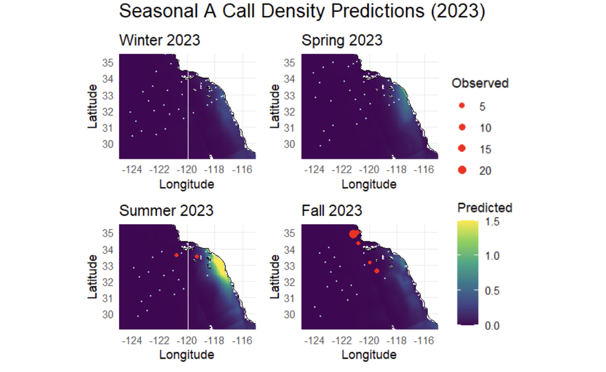

#### Conclusion and Recommendations

The best model failed to accurately predict hotspots and seasonal patterns of presence, highlighting a key discrepancy between predicted and observed acoustic detections. Although the model produced a low RMSE, this metric proved misleading due to the zero-inflated nature of the data, which masks poor spatial and temporal fit. The inclusion of temperature, latitude, and longitude at 55 meters depth was insufficient to explain the observed patterns, suggesting that important ecological drivers may be missing from the dataset or that there is an overall lack of sufficient observations to capture the underlying processes.

To improve future models, we recommend increasing the volume and coverage of acoustic data to better capture spatial and temporal variability. Additionally, incorporating more meaningful predictors—such as biological and behavioral variables relevant to whale activity—could enhance model performance. Finally, we suggest using modeling approaches that are specifically designed to handle zero-inflated data and rare event detection, which would better account for the challenges inherent in this type of ecological data.